# ForageModv02 Supplementary Analysis

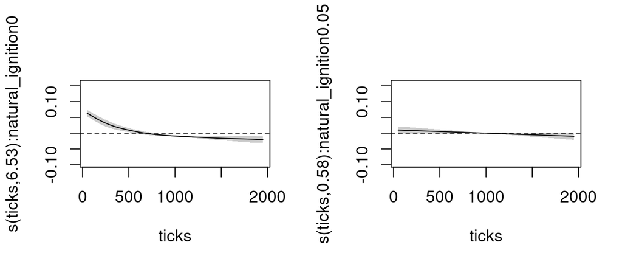

```r
dw.gam1 = gam(shannon.div ~ s(ticks, by = natural_ignition) +
                s(ticks, by = veg_cycle_start) +
                s(ticks, by = veg_distribution) +
                s(ticks, by = burn_cost)  +
                s(ticks, by = burn_veg_type_threshold) +
                s(ticks, by = as.factor(burnt_neighbor_limit)) +
                s(ticks, by = cycle_duration), data = veg.data.d)

par(mfrow=c(1,2), cex=1.1)
plot(dw.gam1, select=1, shade=T)
abline(h=0, lty = 2)
plot(dw.gam1, select=2, shade=T)
abline(h=0, lty = 2)
```

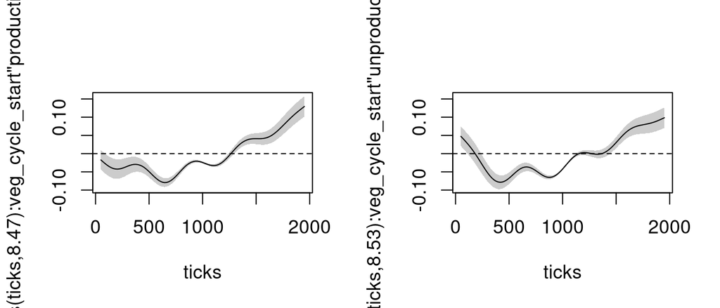

```r
par(mfrow=c(1,2), cex=1.1)
plot(dw.gam1, select=3, shade=T)
abline(h=0, lty = 2)
plot(dw.gam1, select=4, shade=T)
abline(h=0, lty = 2)
```

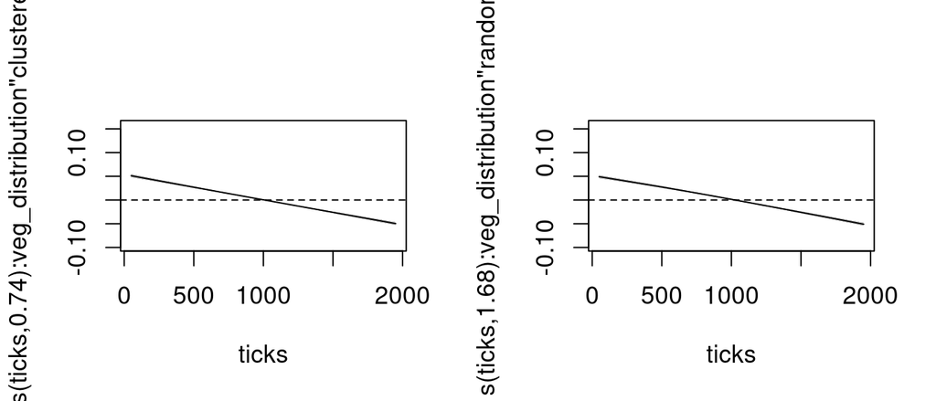

```r
par(mfrow=c(1,2), cex=1.1)
plot(dw.gam1, select=5, shade=T)
abline(h=0, lty = 2)
plot(dw.gam1, select=6, shade=T)
abline(h=0, lty = 2)
```

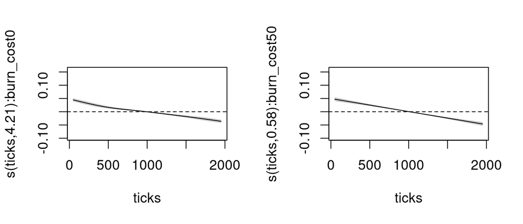

```r
par(mfrow=c(1,2), cex=1.1)
plot(dw.gam1, select=7, shade=T)
abline(h=0, lty = 2)
plot(dw.gam1, select=8, shade=T)
abline(h=0, lty = 2)
```

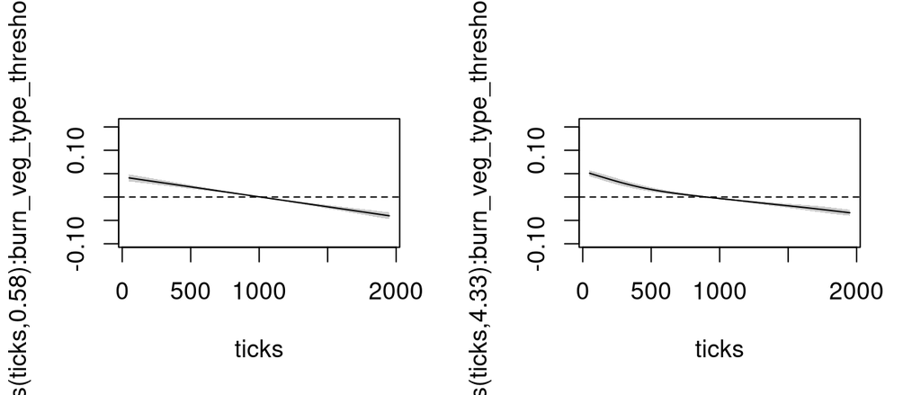

```r
par(mfrow=c(1,2), cex=1.1)
plot(dw.gam1, select=9, shade=T)
abline(h=0, lty = 2)
plot(dw.gam1, select=10, shade=T)
abline(h=0, lty = 2)
```

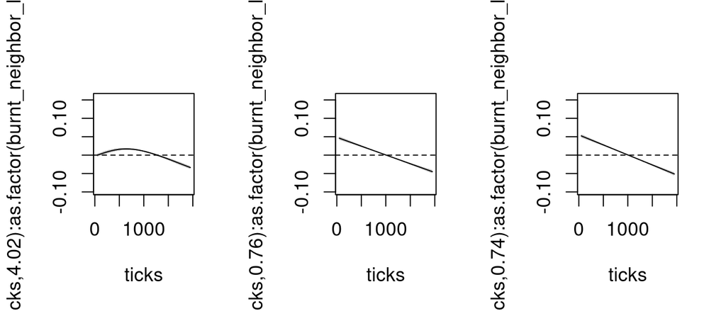

```r
par(mfrow=c(1,3), cex=1.1)
plot(dw.gam1, select=11, shade=T)
abline(h=0, lty = 2)
plot(dw.gam1, select=12, shade=T)
abline(h=0, lty = 2)
plot(dw.gam1, select=13, shade=T)
abline(h=0, lty = 2)
```

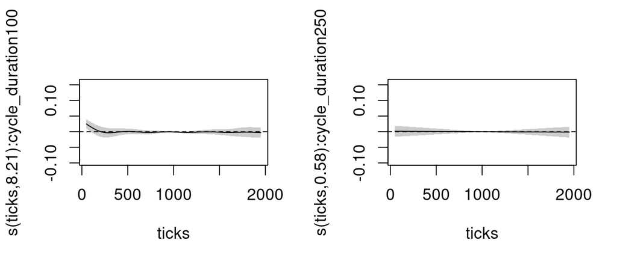

```r
par(mfrow=c(1,2), cex=1.1)
plot(dw.gam1, select=14, shade=T)
abline(h=0, lty = 2)
plot(dw.gam1, select=15, shade=T)
abline(h=0, lty = 2)
```

## Spatial distribution of burning events

We also looked at the spatial autocorrelation of where burning events occur within the landscape to assess land use by the agents. This analysis is split *cycle-duration.* We first use linear regressions to assess how the parameters and time affect the spatial autocorrelation of burning events. For this, we only consider significant values of Moran’s I to evaluate clustering (positive values) and dispersion (negative values).

|  | cycle = 100 ticks | cycle = 250 ticks |
| --- | --- | --- |
| (Intercept) | 0.034174 *** | 0.030760 *** |
|  | (0.004449) | (0.004459) |
| ticks | 0.000005 | 0.000004 |
|  | (0.000004) | (0.000004) |
| natural_ignition0.05 | -0.013553 *** | -0.010688 *** |
|  | (0.002912) | (0.002935) |
| veg_cycle_start"unproductive" | -0.002730 | 0.000598 |
|  | (0.002911) | (0.002935) |
| veg_distribution"random" | -0.011103 *** | -0.014682 *** |
|  | (0.002939) | (0.002958) |
| burnt_neighbor_limit4 | 0.040049 *** | 0.040195 *** |
|  | (0.003570) | (0.003592) |
| burnt_neighbor_limit8 | -0.006482 | -0.004741 |
|  | (0.003578) | (0.003614) |
| burn_cost50 | -0.003345 | -0.001407 |
|  | (0.002912) | (0.002936) |
| burn_veg_type_threshold7 | 0.011317 *** | 0.010655 *** |
|  | (0.002926) | (0.002948) |
| movement_model"Random Walk" | 0.044785 *** | 0.048360 *** |
|  | (0.003032) | (0.003039) |
| ticks:natural_ignition0.05 | 0.000013 *** | 0.000013 *** |
|  | (0.000002) | (0.000002) |
| ticks:veg_cycle_start"unproductive" | 0.000002 | 0.000001 |
|  | (0.000002) | (0.000002) |
| ticks:veg_distribution"random" | -0.000121 *** | -0.000119 *** |
|  | (0.000002) | (0.000002) |
| ticks:burnt_neighbor_limit4 | 0.000053 *** | 0.000053 *** |
|  | (0.000003) | (0.000003) |
| ticks:burnt_neighbor_limit8 | 0.000150 *** | 0.000149 *** |
|  | (0.000003) | (0.000003) |
| ticks:burn_cost50 | 0.000011 *** | 0.000011 *** |
|  | (0.000002) | (0.000002) |
| ticks:burn_veg_type_threshold7 | -0.000049 *** | -0.000046 *** |
|  | (0.000002) | (0.000002) |
| ticks:movement_model"Random Walk" | 0.000038 *** | 0.000036 *** |
|  | (0.000002) | (0.000002) |
| N | 11205 | 11194 |
| R2 | 0.728143 | 0.722829 |
| *** p < 0.001; ** p < 0.01; * p < 0.05. |  |  |

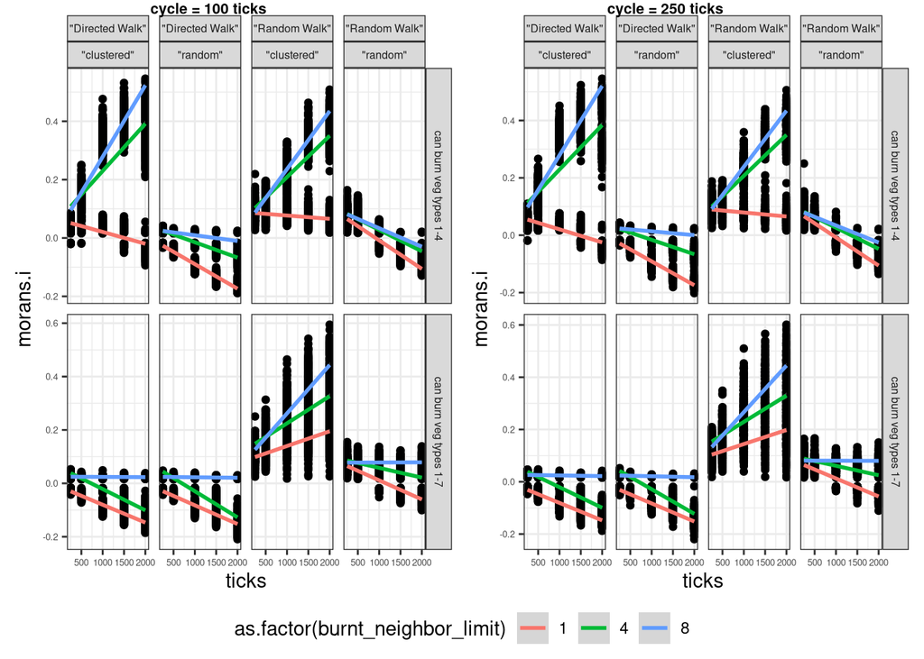

Looking at the spatial autocorrelation by these parameters through time, we can see that strict burning limits typically result in dispersion of burning events (Moran’s I < 0). High clustering of burning events only occurs when the resource potential on the landscape is also clustered. However, as we can see in the above graph, this is also affected by burning limits.

## Forager mobility

In the model, foragers adjust how many steps they take during a foraging bout if they determine they will meet their energy requirements with fewer steps.

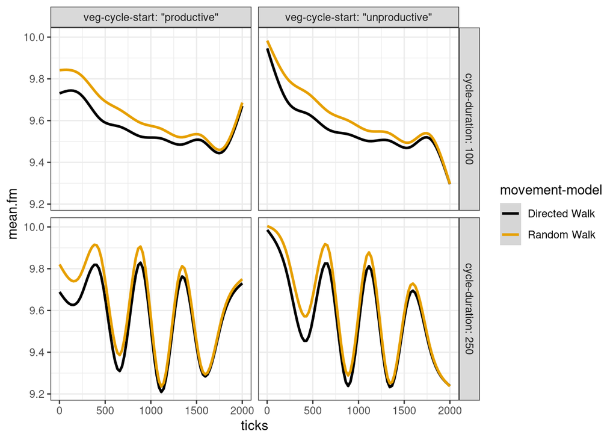

Movement in the model is, therefore, patterned primarily by the energy available in the gridded landscape, which is determined by whether the model is in a productive or unproductive climatic period and how long those climatic periods last.

While cycle duration clearly causes fluctuations in agent movement behaviors, we chose to investigate average steps per foraging bout as a linear trend, splitting the data by cycle duration. Using mixed linear models, we can see how the other parameters affect forager movement while controlling for starting vegetation state.

```r
c100 = data %>% filter(`cycle-duration` == 100) %>% filter(ticks > 0)
c250 = data %>% filter(`cycle-duration` == 250) %>% filter(ticks > 0)

mm.fit1.1 = lmer(mean.fm ~ ticks + (1 | `movement-model`)  + (1 | `veg-cycle-start`), data = c100)

mm.fit1.2 = lmer(mean.fm ~ ticks + `veg-distribution` + `burnt-neighbor-limit` + `burn-cost` + `burn-veg-type-threshold` + `natural-ignition` + (1 | `veg-cycle-start`), data = c100)

mm.fit1.3 = lmer(mean.fm ~ ticks*(`veg-distribution` + `burnt-neighbor-limit` + `burn-cost` + `burn-veg-type-threshold` + `natural-ignition`) + (1 | `veg-cycle-start`), data = c100)

mm.fit1.4 = lmer(mean.fm ~ ticks*(`veg-distribution` + `burnt-neighbor-limit` + `burn-cost` + `burn-veg-type-threshold` + `natural-ignition`) + (1 | `veg-cycle-start`) + (1 | `movement-model`), data = c100)
anova(mm.fit1.1, mm.fit1.2, mm.fit1.3, mm.fit1.4)
```

```
## Data: c100
## Models:
## mm.fit1.1: mean.fm ~ ticks + (1 | `movement-model`) + (1 | `veg-cycle-start`)
## mm.fit1.2: mean.fm ~ ticks + `veg-distribution` + `burnt-neighbor-limit` + `burn-cost` + `burn-veg-type-threshold` + `natural-ignition` + (1 | `veg-cycle-start`)
## mm.fit1.3: mean.fm ~ ticks * (`veg-distribution` + `burnt-neighbor-limit` + `burn-cost` + `burn-veg-type-threshold` + `natural-ignition`) + (1 | `veg-cycle-start`)
## mm.fit1.4: mean.fm ~ ticks * (`veg-distribution` + `burnt-neighbor-limit` + `burn-cost` + `burn-veg-type-threshold` + `natural-ignition`) + (1 | `veg-cycle-start`) + (1 | `movement-model`)
##           npar    AIC    BIC  logLik deviance  Chisq Df Pr(>Chisq)
## mm.fit1.1    5 754226 754294 -377108   754216
## mm.fit1.2   10 284084 284219 -142032   284064 470152  5  < 2.2e-16 ***
## mm.fit1.3   16 209166 209383 -104567   209134  74930  6  < 2.2e-16 ***
## mm.fit1.4   17 129345 129575  -64655   129311  79823  1  < 2.2e-16 ***
## ---
## Signif. codes:  0 '***' 0.001 '**' 0.01 '*' 0.05 '.' 0.1 ' ' 1
```

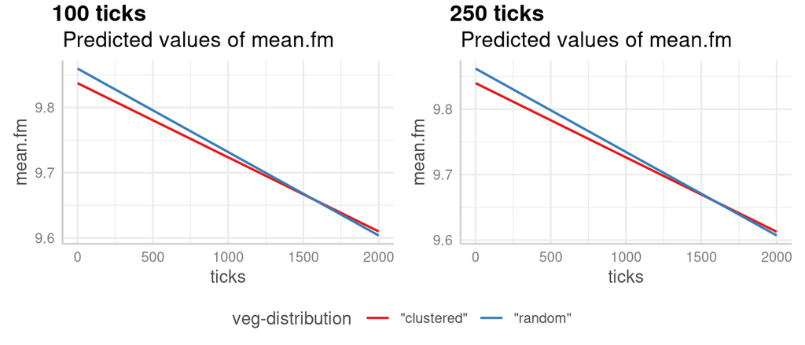

```r
mm.fit2.4 = lmer(mean.fm ~ ticks*(`veg-distribution` + `burnt-neighbor-limit` + `burn-cost` + `burn-veg-type-threshold` + `natural-ignition`) + (1 | `veg-cycle-start`) + (1 | `movement-model`), data = c250)

ggpubr::ggarrange(
  ggeffects::ggpredict(mm.fit1.4, terms = c("ticks", "veg-distribution")) %>%
    plot(show_data = FALSE, show_ci = FALSE),
  ggeffects::ggpredict(mm.fit2.4, terms = c("ticks", "veg-distribution")) %>%
    plot(show_data = FALSE, show_ci = FALSE),
  common.legend = T, labels = c("100 ticks", "250 ticks"), legend = "bottom", vjust = -0.1
) +
  theme(plot.margin = margin(0.5,0.1,0.1,0.1, "cm"))
```

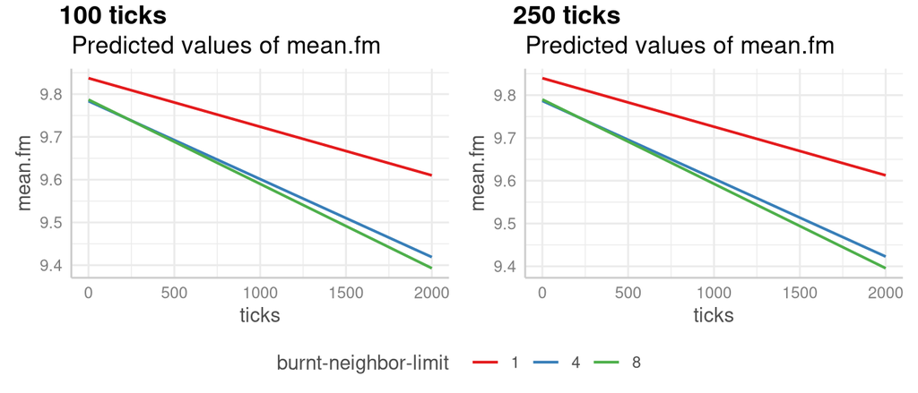

```r
ggpubr::ggarrange(
  ggeffects::ggpredict(mm.fit1.4, terms = c("ticks", "burnt-neighbor-limit")) %>%
    plot(show_data = FALSE, show_ci = FALSE),
  ggeffects::ggpredict(mm.fit2.4, terms = c("ticks", "burnt-neighbor-limit")) %>%
    plot(show_data = FALSE, show_ci = FALSE),
  common.legend = T, labels = c("100 ticks", "250 ticks"), legend = "bottom", vjust = -0.1
) +
  theme(plot.margin = margin(0.5,0.1,0.1,0.1, "cm"))
```

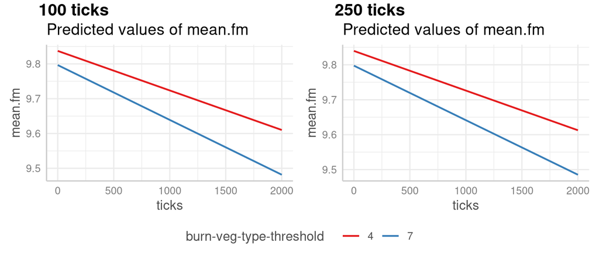

```r
ggpubr::ggarrange(
  ggeffects::ggpredict(mm.fit1.4, terms = c("ticks", "burn-veg-type-threshold")) %>%
    plot(show_data = FALSE, show_ci = FALSE),
  ggeffects::ggpredict(mm.fit2.4, terms = c("ticks", "burn-veg-type-threshold")) %>%
    plot(show_data = FALSE, show_ci = FALSE),
  common.legend = T, labels = c("100 ticks", "250 ticks"), legend = "bottom", vjust = -0.1
) +
  theme(plot.margin = margin(0.5,0.1,0.1,0.1, "cm"))
```

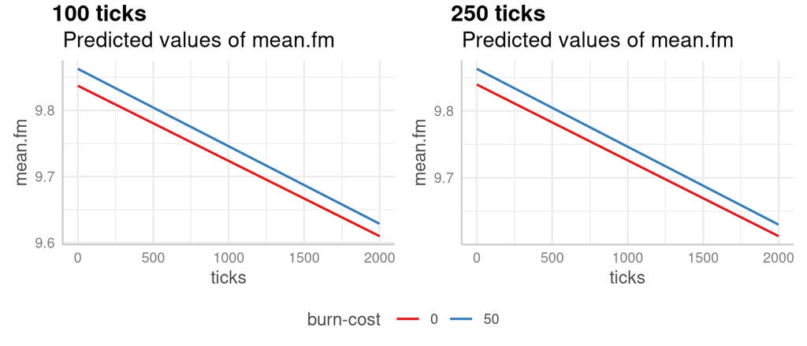

```r
ggpubr::ggarrange(
  ggeffects::ggpredict(mm.fit1.4, terms = c("ticks", "burn-cost")) %>%
    plot(show_data = FALSE, show_ci = FALSE),
  ggeffects::ggpredict(mm.fit2.4, terms = c("ticks", "burn-cost")) %>%
    plot(show_data = FALSE, show_ci = FALSE),
  common.legend = T, labels = c("100 ticks", "250 ticks"), legend = "bottom", vjust = -0.1
) +
  theme(plot.margin = margin(0.5,0.1,0.1,0.1, "cm"))
```

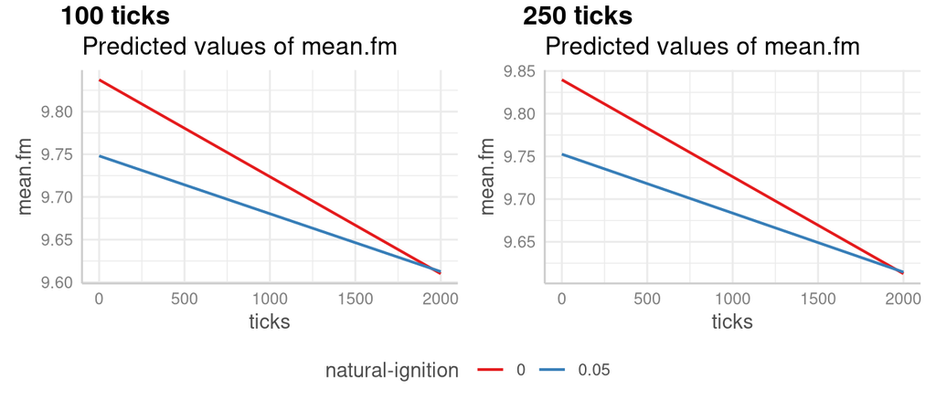

```r
ggpubr::ggarrange(
  ggeffects::ggpredict(mm.fit1.4, terms = c("ticks", "natural-ignition")) %>%
    plot(show_data = FALSE, show_ci = FALSE),
  ggeffects::ggpredict(mm.fit2.4, terms = c("ticks", "natural-ignition")) %>%
    plot(show_data = FALSE, show_ci = FALSE),
  common.legend = T, labels = c("100 ticks", "250 ticks"), legend = "bottom", vjust = -0.1
) +
  theme(plot.margin = margin(0.5,0.1,0.1,0.1, "cm"))
```

These models demonstrate that strict burning limits lead to higher mobility across model run. When burning is more frequent, mobility decreases quickly over model run.

## Forager interactions

When looking at forager interactions, we have to consider them in relation to populations since more foragers on the landscape will necessarily mean more possible interactions. The model outputs interaction counts averaged across all agents and we divided this by the population count to get the average proportion of the population that an individual agent interacts with each tick.

First, we investigate parameter effects via linear regression.

```r
# ggplot(data %>% filter(ticks > 0)) +
#   geom_density(aes(x = log(adj.fi)))
# summary(data$adj.fi)
summary(log(data$adj.fi))
```

```
##    Min. 1st Qu.  Median    Mean 3rd Qu.    Max.
##    -Inf -4.2873 -4.2526    -Inf -4.2132 -0.6931
```

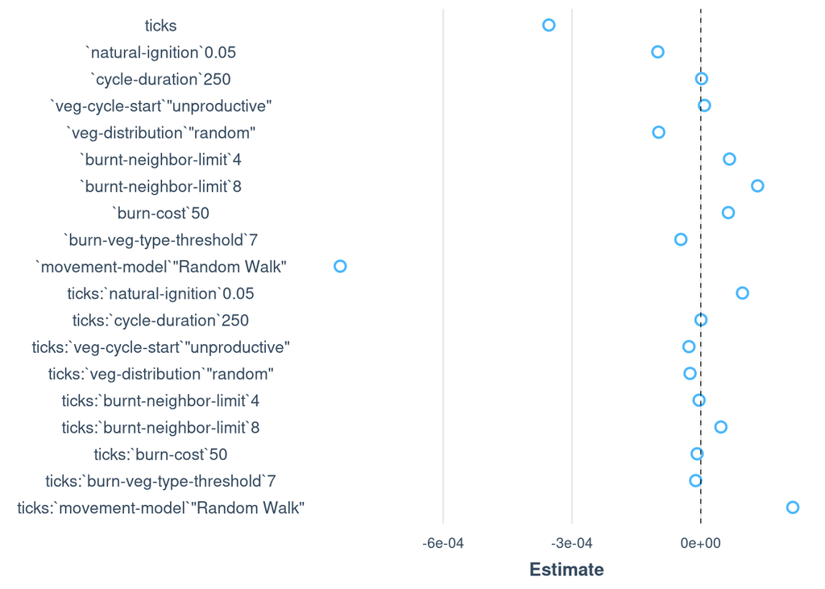

```r
parameters = c(
  "natural-ignition", # 0.00, 0.05
  "cycle-duration",  # 100, 250
  "veg-cycle-start", # productive, unproductive
  "veg-distribution", # random, clustered
  "burnt-neighbor-limit", # 1, 4, 8
  "burn-cost", # 0, 50
  "burn-veg-type-threshold", # 4, 7
  "movement-model" #Random, Directed
)

fi.fit1 = lm(adj.fi ~ ticks*(.), data = data %>% dplyr::select_at(c(parameters, "ticks", "adj.fi")) %>% filter(ticks > 0))

plot_summs(fi.fit1, scale = T)
```

By comparing standardized regression coefficients, we can see the greatest effect on forager interactions is between movement models.

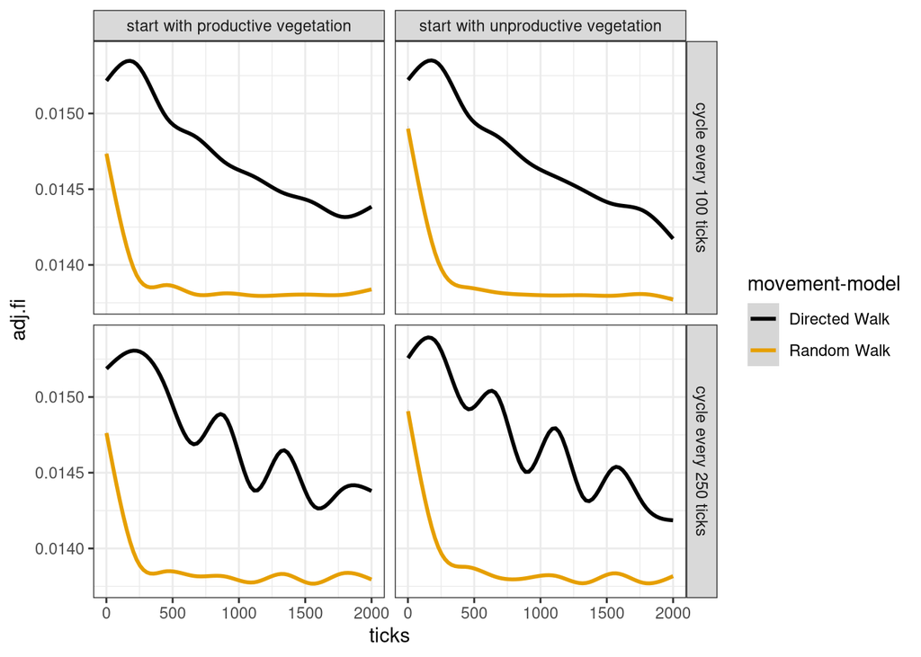

When we visualize these differences, we can see that random walks result in a steep drop off. This means that a linear model is probably not the best fit, which is confirmed by the QQ-plot for the random walk data.

For this reason, we split the regression of the random walk data into two segments.

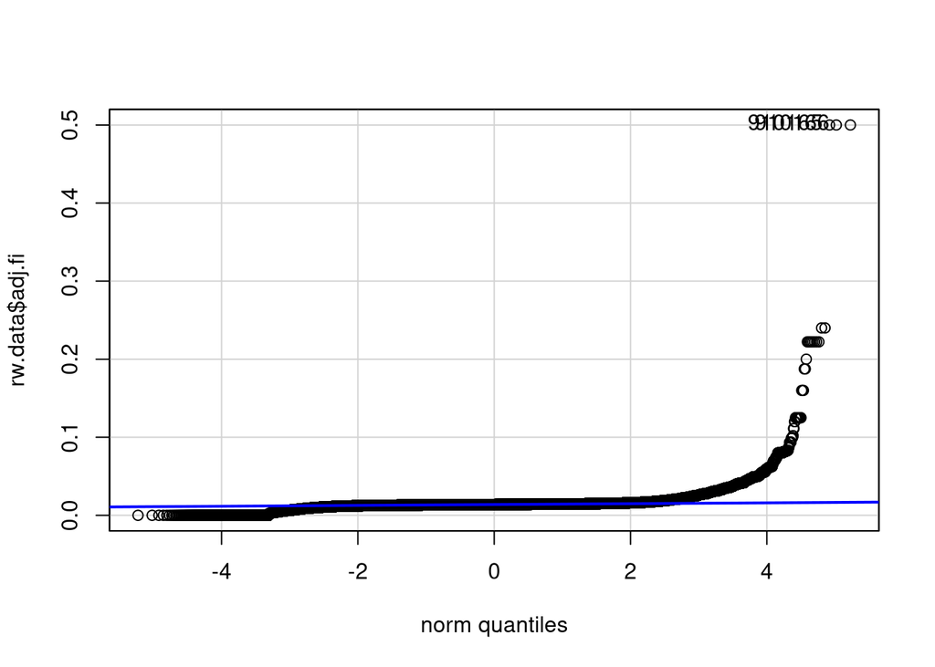

```
## [1] 910165 910166
```

```r
rw.data = data %>% filter(`movement-model` == "\"Random Walk\"") %>% filter(ticks > 0)
dw.data = data %>% filter(`movement-model` == "\"Directed Walk\"") %>% filter(ticks > 0)

car::qqPlot(rw.data$adj.fi)
```

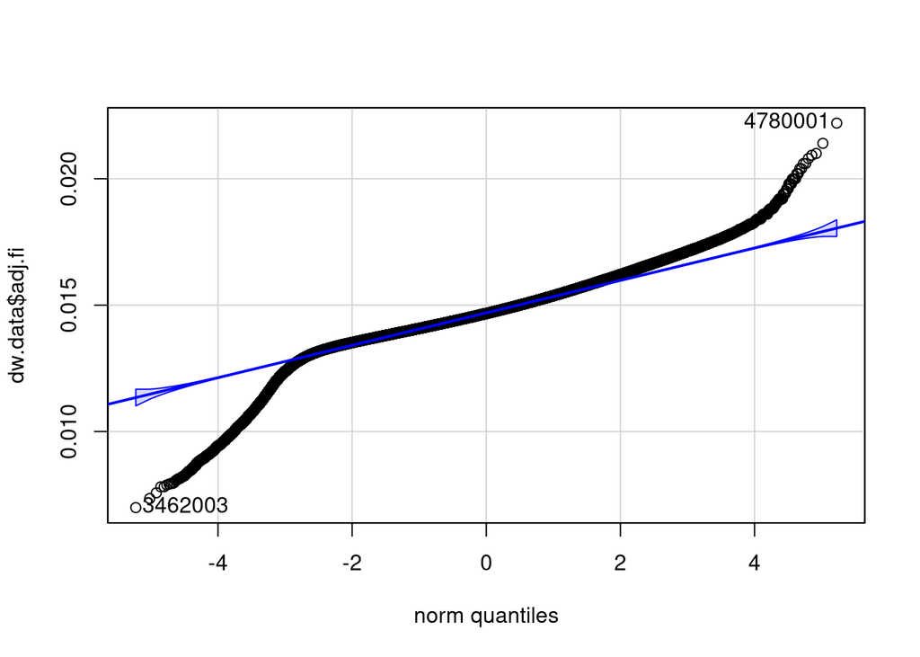

```
## [1] 3462003 4780001
```

```r
car::qqPlot(dw.data$adj.fi)
```

```r
dw.fit1 = lm(adj.fi ~ ticks*(.), data = dw.data %>% filter(ticks > 0) %>% select_at(c("ticks", "adj.fi", parameters[-8])))

rw.fit1 = lm(adj.fi ~ ticks*(.), data = rw.data %>% filter(ticks > 0) %>% select_at(c("ticks", "adj.fi", parameters[-8])))

rw.fit2 = segmented::segmented(rw.fit1, seg.Z = ~ ticks, psi = list(ticks = c(250)))
#summary(rw.fit2)
rw.fit2$psi
```

[output not shown]

```r
segmented::slope(rw.fit2)
```

```
## $ticks
##               Est.    St.Err.  t value   CI(95%).l   CI(95%).u
## slope1 -4.3200e-06 2.6227e-08 -164.710 -4.3714e-06 -4.2686e-06
## slope2 -1.2882e-07 3.0626e-09  -42.064 -1.3483e-07 -1.2282e-07
```

```r
# plotNormalDensity((rw.data %>% filter(ticks < 216))$adj.fi)
# plotNormalDensity((rw.data %>% filter(ticks > 216))$adj.fi)

rw.fit3 = lm(adj.fi ~ ticks*(.), data = rw.data %>% filter(ticks > 0) %>% select_at(c("ticks", "adj.fi", parameters[-8])) %>% filter(ticks < 216))

rw.fit4 = lm(adj.fi ~ ticks*(.), data = rw.data %>% filter(ticks > 0) %>% select_at(c("ticks", "adj.fi", parameters[-8])) %>% filter(ticks > 216))

# dw.fit1 %>% broom::tidy() %>%
#   filter(p.value <= 0.05) %>%
#   mutate(p.value = scales::pvalue(p.value)) %>%
#   kable()

rw.fit3 %>% broom::tidy() %>% full_join((rw.fit4 %>% broom::tidy()), by = "term") %>%
  select(term, estimate.x, p.value.x, estimate.y, p.value.y) %>%
  filter(p.value.y <= 0.05 | p.value.x <= 0.05) %>%
  mutate(p.value.x = scales::pvalue(p.value.x),
         p.value.y =scales::pvalue(p.value.y)) %>%
  rename(part_1_estimate = estimate.x,
         part_1_pvalue = p.value.x,
         part_2_estimate = estimate.y,
         part_2_pvalue = p.value.y) %>%
  kable()
```

| term | part_1_estimate | part_1_pvalue | part_2_estimate | part_2_pvalue |
| --- | --- | --- | --- | --- |
| (Intercept) | 0.0153617 | <0.001 | 0.0139116 | <0.001 |
| ticks | -0.0000073 | <0.001 | -0.0000001 | <0.001 |
| `natural-ignition`0.05 | -0.0012825 | <0.001 | -0.0000417 | <0.001 |
| `cycle-duration`250 | 0.0000298 | 0.125 | 0.0000052 | <0.001 |
| `veg-cycle-start`“unproductive” | 0.0001061 | <0.001 | 0.0000152 | <0.001 |
| `veg-distribution`“random” | -0.0001121 | <0.001 | -0.0001245 | <0.001 |
| `burnt-neighbor-limit`4 | 0.0000608 | 0.011 | -0.0000016 | 0.315 |
| `burnt-neighbor-limit`8 | 0.0000106 | 0.656 | -0.0000062 | <0.001 |
| `burn-cost`50 | 0.0001513 | <0.001 | 0.0000532 | <0.001 |
| `burn-veg-type-threshold`7 | -0.0000038 | 0.847 | 0.0000188 | <0.001 |
| ticks:`natural-ignition`0.05 | 0.0000055 | <0.001 | 0.0000000 | <0.001 |
| ticks:`cycle-duration`250 | -0.0000003 | 0.034 | 0.0000000 | 0.002 |
| ticks:`veg-cycle-start`“unproductive” | 0.0000005 | 0.002 | 0.0000000 | <0.001 |
| ticks:`veg-distribution`“random” | 0.0000000 | 0.751 | 0.0000000 | <0.001 |
| ticks:`burnt-neighbor-limit`4 | -0.0000003 | 0.131 | 0.0000000 | <0.001 |
| ticks:`burnt-neighbor-limit`8 | 0.0000001 | 0.471 | 0.0000000 | <0.001 |
| ticks:`burn-cost`50 | 0.0000001 | 0.427 | 0.0000000 | <0.001 |
| ticks:`burn-veg-type-threshold`7 | 0.0000001 | 0.512 | 0.0000000 | <0.001 |

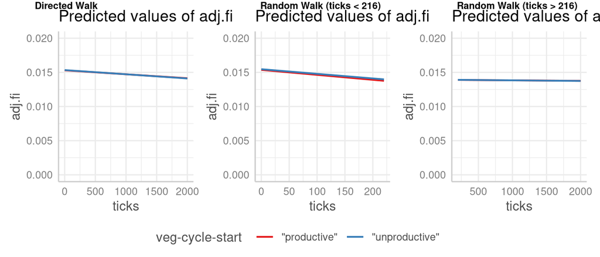

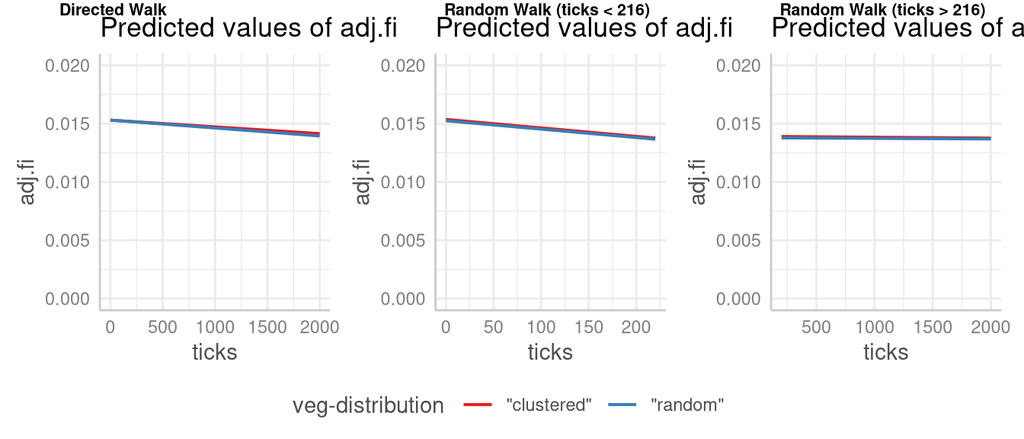

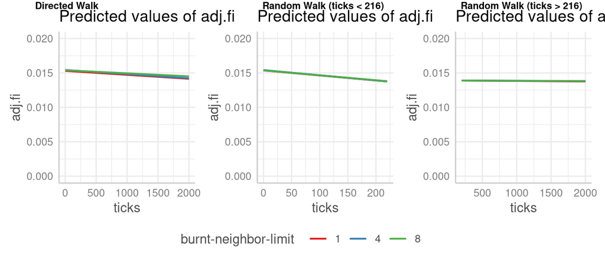

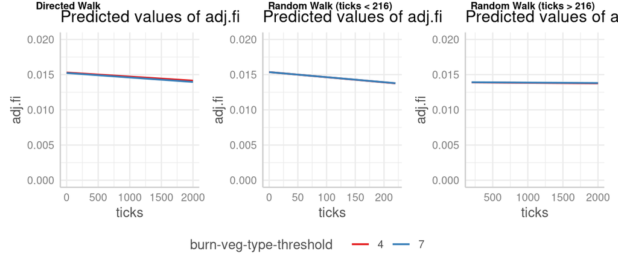

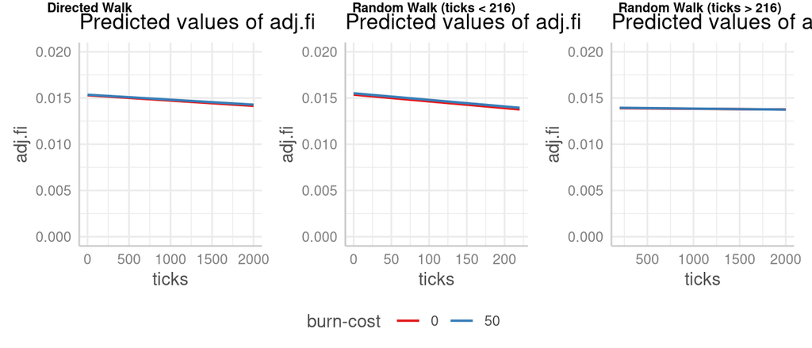

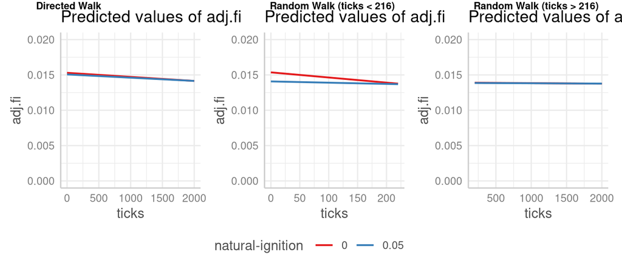

As noted above, the only parameter that seems to have varied effects on the initial forager interactions for random walks is *natural-ignition.* For this reason, we focus on comparing directed walk data and the second segment of random walk data.

When the underlying distribution of resource potential is clustered, we see more forager interactions than when that distribution is random. We also see more forager interactions when burning behaviors are not limited by burnt neighboring patches. This is interesting because the other two burning parameters, *burn-veg-type-threshold* and *burn-cost*, show increased forager interactions with stricter burning limits.